# Fitting the ST model for the LUR

```
Optimisation using starting value 11/17
```

[output not shown]

```
Optimisation using starting value 12/17
```

[output not shown]

```
Optimisation using starting value 13/17
```

[output not shown]

```
Optimisation using starting value 14/17
```

[output not shown]

```
Optimisation using starting value 15/17
```

[output not shown]

```
Optimisation using starting value 16/17
```

[output not shown]

```
NaNs producedOptimisation using starting value 17/17
```

[output not shown]

```r
print(est.denver.model.exp)
```

```
Optimisation for STmodel with 17 starting points.
  Results: 7 converged, 10 not converged, 0 failed.
  Best result for starting point 14, optimisation has converged

No fixed parameters.

Estimated parameters for all starting point(s):
                                       [,1]          [,2]          [,3]          [,4]          [,5]          [,6]
gamma.bc_st_no2               -5.034598e-03  -0.005035775 -5.035302e-03 -5.037097e-03 -5.034706e-03  -0.005035775
alpha.const.(Intercept)        4.101747e-01   0.410187482  4.101810e-01  4.102085e-01  4.101766e-01   0.410187482
alpha.const.tree_cover_100    -1.147530e-03  -0.001138142 -1.142946e-03 -1.131056e-03 -1.146428e-03  -0.001138142
alpha.const.low_int_100        3.256460e-03   0.003257619  3.258766e-03  3.256775e-03  3.255919e-03   0.003257619
alpha.const.dist_m_military   -7.329231e-03  -0.007335843 -7.338140e-03 -7.341456e-03 -7.327092e-03  -0.007335843
alpha.const.dist_m_rail        3.865002e-03   0.003866030  3.863383e-03  3.867540e-03  3.866118e-03   0.003866030
alpha.const.aadt_100           4.371809e-02   0.043686084  4.370953e-02  4.367124e-02  4.370993e-02   0.043686084
alpha.V1.(Intercept)          -3.122251e-01  -0.312226456 -3.122167e-01 -3.122335e-01 -3.122295e-01  -0.312226456
alpha.V1.tree_cover_100        1.158010e-02   0.011572582  1.157544e-02  1.156732e-02  1.157967e-02   0.011572582
alpha.V1.low_int_100           1.143389e-02   0.011435066  1.143729e-02  1.143668e-02  1.143246e-02   0.011435066
alpha.V1.dist_m_military       6.931269e-04   0.000700652  6.919855e-04  7.093756e-04  6.960914e-04   0.000700652
alpha.V1.dist_m_rail          -5.953636e-02  -0.059539805 -5.954387e-02 -5.954174e-02 -5.953387e-02  -0.059539805
alpha.V1.aadt_100              5.524499e-02   0.055262253  5.529302e-02  5.525785e-02  5.522929e-02   0.055262253
log.range.const.exp            0.000000e+00   0.000000000  0.000000e+00  0.000000e+00  0.000000e+00   2.000000000
log.sill.const.exp            -6.177789e+00  -6.171372906 -6.174121e+00 -6.176080e+00 -6.176133e+00  -6.171372906
log.nugget.const.exp          -1.285012e+01 -15.000000000 -1.500000e+01 -1.077703e+01 -1.469293e+01 -15.000000000
log.nugget.V1.iid             -5.723433e+00  -5.721857442 -5.719841e+00 -5.720955e+00 -5.724559e+00  -5.721857442
nu.log.range.exp               0.000000e+00   0.000000000  0.000000e+00  0.000000e+00  0.000000e+00   2.000000000
nu.log.sill.exp               -2.638822e+00  -2.640316011 -2.639916e+00 -2.641881e+00 -2.639480e+00  -2.640316011
nu.log.nugget.(Intercept).exp -2.616949e+00  -2.615642447 -2.616046e+00 -2.614124e+00 -2.616095e+00  -2.615642447
                                       [,7]          [,8]          [,9]         [,10]         [,11]         [,12]
gamma.bc_st_no2               -5.035302e-03 -5.037097e-03 -5.034706e-03  -0.006884406 -6.883390e-03 -6.883683e-03
alpha.const.(Intercept)        4.101810e-01  4.102085e-01  4.101766e-01   0.444380029  4.443503e-01  4.443270e-01
alpha.const.tree_cover_100    -1.142946e-03 -1.131056e-03 -1.146428e-03   0.008958104  8.955166e-03  8.951121e-03
alpha.const.low_int_100        3.258766e-03  3.256775e-03  3.255919e-03  -0.006931977 -6.921125e-03 -6.926386e-03
alpha.const.dist_m_military   -7.338140e-03 -7.341456e-03 -7.327092e-03  -0.013384498 -1.338814e-02 -1.339159e-02
alpha.const.dist_m_rail        3.863383e-03  3.867540e-03  3.866118e-03   0.004953257  4.956233e-03  4.963254e-03
alpha.const.aadt_100           4.370953e-02  4.367124e-02  4.370993e-02   0.044199687  4.421881e-02  4.419217e-02
alpha.V1.(Intercept)          -3.122167e-01 -3.122335e-01 -3.122295e-01  -0.327626938 -3.275976e-01 -3.275710e-01
alpha.V1.tree_cover_100        1.157544e-02  1.156732e-02  1.157967e-02   0.000661156  6.639508e-04  6.608703e-04
alpha.V1.low_int_100           1.143729e-02  1.143668e-02  1.143246e-02   0.014972181  1.496968e-02  1.498063e-02
alpha.V1.dist_m_military       6.919855e-04  7.093756e-04  6.960914e-04   0.009853794  9.852449e-03  9.851175e-03
```

[output cut: 19 more lines]

```
alpha.V1.low_int_100           1.497258e-02  1.497316e-02  1.497689e-02  1.446075e-02  1.498281e-02
alpha.V1.dist_m_military       9.863179e-03  9.850732e-03  9.848643e-03  1.214598e-02  9.819336e-03
alpha.V1.dist_m_rail          -4.814741e-02 -4.814901e-02 -4.816131e-02 -4.467967e-02 -4.816668e-02
alpha.V1.aadt_100              5.632574e-02  5.635217e-02  5.641926e-02  3.767008e-02  5.645866e-02
log.range.const.exp            3.985245e+00  2.730811e+00  3.753609e+00  3.533522e+00  3.175425e+00
log.sill.const.exp            -6.079062e+00 -6.070467e+00 -6.068014e+00 -6.020509e+00 -6.078108e+00
log.nugget.const.exp          -1.043036e+01 -1.500000e+01 -1.500000e+01 -1.481062e+01 -1.487368e+01
log.nugget.V1.iid             -5.866325e+00 -5.865629e+00 -5.859760e+00 -1.355445e+01 -5.857595e+00
nu.log.range.exp               8.597610e+00  8.597500e+00  8.597300e+00  8.614001e+00  8.597778e+00
nu.log.sill.exp               -2.267671e+00 -2.267540e+00 -2.267142e+00 -2.274828e+00 -2.267794e+00
nu.log.nugget.(Intercept).exp -2.908573e+00 -2.908793e+00 -2.909411e+00 -2.857363e+00 -2.908383e+00

Function value(s):
 [1] 522.1327 522.1332 522.1332 522.1290 522.1332 522.1332 522.1332 522.1290 522.1332 558.0034 557.9982 558.0034 557.9938
[14] 558.0034 558.0032 556.7883 558.0033
```

### Step 5: Predictions

In order to get this to work, I’m going to use with `only.obs = T` option. When I tried to use the predict function without setting `only.obs = T`, I got NA values in each of the columns for the pred$LAT object.

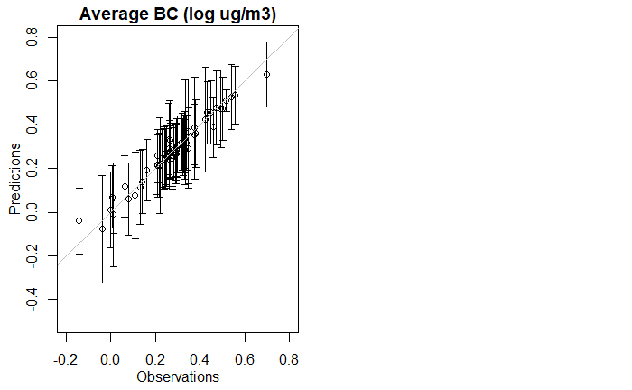

### Step 6: Cross-validation and model evaluation

Josh recommended 10-fold CV for the distributed sites and LOOCV for the monitor. These will need to be separate processes.

However, it might not make sense to do LOOCV for the central site because we only have the one. I’ll skip it for now, but come back to this in the future

#### Step 6.1: Define CV groups

```r
unique(colnames(bc_obs))
```

```
 [1] "central" "d_2"     "d_4"     "d_6"     "d_8"     "d_12"    "d_14"    "d_16"    "d_18"    "d_20"    "d_22"    "d_24"
[13] "d_26"    "d_5"     "d_7"     "d_11"    "d_13"    "d_15"    "d_17"    "d_19"    "d_21"    "d_23"    "d_25"    "d_3"
[25] "d_10"    "d_28"    "d_30"    "d_32"    "d_34"    "d_36"    "d_38"    "d_40"    "d_41"    "d_42"    "d_43"    "d_44"
[37] "d_45"    "d_1"     "d_9"     "d_27"    "d_29"    "d_31"    "d_33"    "d_37"    "d_39"    "d_35"    "d_49"    "d_51"
[49] "d_52"    "d_55"    "d_56"    "d_46"    "d_47"    "d_50"    "d_53"    "d_54"    "d_48"    "d_57"    "d_58"    "d_59"
[61] "d_60"
```

```r
Ind.cv <- createCV(denver.model.exp, groups = 10, min.dist = .1,
                   subset = paste0("d_", 1:60))
```

The number of locations is roughly even, though the number of observations differs by group– remember! This is an unbalanced design

```r
ID.cv <- sapply(split(denver.model.exp$obs$ID, Ind.cv), unique)
print(sapply(ID.cv, length))
```

```
 0  1  2  3  4  5  6  7  8  9 10
 1  6  6  6  6  6  6  6  6  6  6
```

```r
table(Ind.cv)
```

```
Ind.cv
  0   1   2   3   4   5   6   7   8   9  10
169 100 101 102 115 103  82  86  86  94 108
```

```r
I.col <- apply(sapply(ID.cv,function(x) denver.model.exp$locations$ID%in% x), 1,
               function(x) if(sum(x)==1) which(x) else 0)
names(I.col) <- denver.model.exp$locations$ID
print(I.col)
```

```
central     d_2     d_4     d_6     d_8    d_12    d_14    d_16    d_18    d_20    d_22    d_24    d_26     d_5     d_7
      1       6       9      11       4      11       2       8      11       9       7       2       9      10       2
   d_11    d_13    d_15    d_17    d_19    d_21    d_23    d_25     d_3    d_10    d_28    d_30    d_32    d_34    d_36
     10      11       6      11       6      10       3       3       8       8       3       5      10       5       4
   d_38    d_40    d_41    d_42    d_43    d_44    d_45     d_1     d_9    d_27    d_29    d_31    d_33    d_37    d_39
      5       4       7       2       7       8       6       2       5       5       4       7       5       9       4
   d_35    d_49    d_51    d_52    d_55    d_56    d_46    d_47    d_50    d_53    d_54    d_48    d_57    d_58    d_59
      3       6       8      11       4       9       9       8      10       2       6       3       3       7       7
   d_60
     10
```

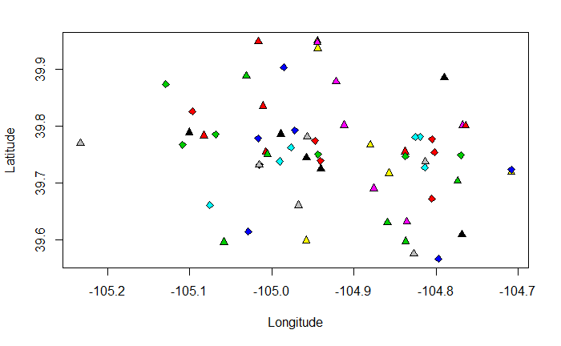

```r
par(mfrow=c(1,1))
plot(denver.model.exp$locations$long,
     denver.model.exp$locations$lat,
     pch=23+floor(I.col/max(I.col)+.5), bg=I.col,
     xlab="Longitude", ylab="Latitude")
```

```r
map("county", "colorado", col="#FFFF0055",fill=TRUE, add=TRUE)
```

#### Step 6.2: ID starting conditions using previous model without CV

|  | par | init |
| --- | --- | --- |
| log.range.const.exp | 2.730811 | 6 |
| log.sill.const.exp | -6.070467 | -1 |
| log.nugget.const.exp | -15.000000 | -1 |
| log.nugget.V1.iid | -5.865629 | -1 |
| nu.log.range.exp | 8.597500 | 6 |
| nu.log.sill.exp | -2.267540 | -1 |
| nu.log.nugget.(Intercept).exp | -2.908793 | 0 |

#### Step 6.3 : Run the model

```r
est.denver.cv.exp <- estimateCV(denver.model.exp, x.init.cv, Ind.cv)
```

```
Estimation of CV-set 1/10
Optimisation using starting value 1/2
```

[output not shown]

```
Optimisation using starting value 2/2
```

[output not shown]

```
Estimation of CV-set 2/10
Optimisation using starting value 1/2
```

[output not shown]

```
Optimisation using starting value 2/2
```

[output not shown]

```
Estimation of CV-set 3/10
Optimisation using starting value 1/2
```

[output not shown]

```
Optimisation using starting value 2/2
```

[output not shown]

```
Estimation of CV-set 4/10
Optimisation using starting value 1/2
```

[output not shown]

```
Optimisation using starting value 2/2
```

[output not shown]

```
Estimation of CV-set 5/10
Optimisation using starting value 1/2
```

[output not shown]

```
Optimisation using starting value 2/2
```

[output not shown]

```
Estimation of CV-set 6/10
Optimisation using starting value 1/2
```

[output not shown]

```
Optimisation using starting value 2/2
```

[output not shown]

```
Estimation of CV-set 7/10
Optimisation using starting value 1/2
```

[output not shown]

```
Optimisation using starting value 2/2
```

[output not shown]

```
Estimation of CV-set 8/10
Optimisation using starting value 1/2
```

[output not shown]

```
Optimisation using starting value 2/2
```

[output not shown]

```
Estimation of CV-set 9/10
Optimisation using starting value 1/2
```

[output not shown]

```
Optimisation using starting value 2/2
```

[output not shown]

```
Estimation of CV-set 10/10
Optimisation using starting value 1/2
```

[output not shown]

```
Optimisation using starting value 2/2
```

[output not shown]

```r
print(est.denver.cv.exp)
```

```
Cross-validation parameter estimation for STmodel
  with 10 CV-groups and 2 starting points.
  Results: 6 converged, 4 not converged.

No fixed parameters.

Estimated function values and convergence info:
```

| value | convergence | conv | eigen.min | eigen.all.min |
| --- | --- | --- | --- | --- |
| 520.1981 | TRUE | TRUE | 2.992915e-04 | NA |
| 531.7903 | TRUE | TRUE | 5.115838e-07 | NA |
| 486.0311 | TRUE | TRUE | 6.821166e-07 | NA |
| 471.9826 | TRUE | TRUE | 8.521772e-08 | NA |
| 489.7303 | TRUE | TRUE | 1.956157e-03 | NA |
| 490.8632 | TRUE | FALSE | -2.966985e-05 | NA |
| 616.5324 | TRUE | FALSE | -2.383000e-07 | NA |
| 611.5582 | TRUE | FALSE | -2.674014e-03 | NA |
| 485.9934 | TRUE | TRUE | 7.672424e-07 | NA |
| 482.2820 | TRUE | FALSE | -2.274703e-07 | NA |

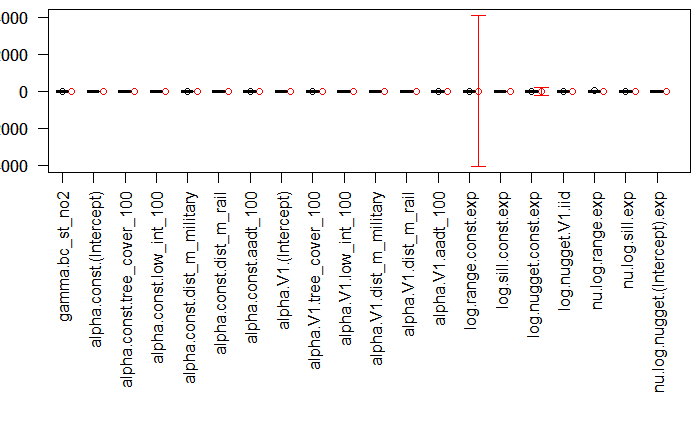

```r
par(mfrow=c(1,1), mar=c(13.5,2.5,.5,.5), las=2)
with(coef(est.denver.model.exp, pars="all"),
     plotCI((1:length(par))+.3, par, uiw=1.96*sd,
            col=2, xlab="", xaxt="n", ylab=""))
boxplot(est.denver.cv.exp, "all", boxwex=.4, col="grey", add=TRUE)
```

```r
#' Save the results as an .rdata object
save(denver.data, denver.model.iid, denver.model.exp,
     est.denver.model.iid, est.denver.model.exp,
     est.denver.cv.exp,
     file = here::here("Results", "Denver_ST_Model.rdata"))
```

#’ Step 7: Prediction using the CV model Making predctions using the CV model. Printing out the CV summary statistics as well

```r
pred.cv <- predictCV(denver.model.exp, est.denver.cv.exp, LTA = T)
pred.cv.log <- predictCV(denver.model.exp, est.denver.cv.exp,
                         LTA = T, transform="unbiased")

names(pred.cv)
```

```
[1] "opts"     "Ind.cv"   "pred.obs" "pred.LTA" "pred.all"
```

```r
summary(pred.cv)
```

```
Cross-validation predictions for STmodel with 10 CV-groups.
  Predictions for 977 observations.
  Temporal averages for 60 locations.

RMSE:
            EX.mu EX.mu.beta        EX
obs     0.4155845  0.4154080 0.4094333
average 0.1262586  0.1257099 0.1192343

R2:
            EX.mu EX.mu.beta        EX
obs     0.2938485  0.2944481 0.3145975
average 0.3213810  0.3272658 0.3947893

Coverage of 95% prediction intervals:
               EX
obs     0.9570113
average 0.9166667
```

```r
summary(pred.cv.log)
```

```
Cross-validation predictions for STmodel with 10 CV-groups.
  Predictions for 977 observations.
  Temporal averages for 60 locations.

RMSE:
            EX.mu EX.mu.beta        EX   EX.pred
obs     0.5887282  0.5879597 0.5352597 0.5341748
average 0.2106346  0.2086718 0.1716694 0.1719332

R2:
            EX.mu EX.mu.beta        EX   EX.pred
obs     0.3792129  0.3808327 0.4868527 0.4889308
average 0.2701692  0.2837075 0.5152156 0.5137244

Coverage of 95% prediction intervals:
          EX.pred
obs     0.9570113
average 0.9500000
```

```r
par(mfrow=c(1,2), mar=c(3.3,3.3,1.5,1), mgp=c(2,1,0))
plot(pred.cv, "obs", ID="all", pch=c(19,NA), cex=.25, lty=c(NA,2),
     col=c("ID", "black", "grey"),
     ylim=c(-1,2),
     xlab="Observations", ylab="Predictions",
     main="Cross-validation BC (log ug/m3)")
with(pred.cv.log$pred.LTA, plotCI(obs, EX.pred, uiw=1.96*sqrt(VX.pred),
                                  xlab="Observations", ylab="Predictions",
                                  main="Temporal average BC (ug/m3)"))
```

[output not shown]

```r
abline(0, 1, col="grey")

jpeg(filename = here::here("Figs", "ST_CV_Obs_vs_Pred_BC.jpeg"),
     width = 8, height = 4, units = "in", res = 500)
```

```r
par(mfrow=c(1,2), mar=c(3.3,3.3,1.5,1), mgp=c(2,1,0))
plot(pred.cv, "obs", ID="all", pch=c(19,NA), cex=.25, lty=c(NA,2),
     col=c("ID", "black", "grey"),
     ylim=c(-1,2),
     xlab="Observations", ylab="Predictions",
     main="A) Cross-validation BC (log ug/m3)")
with(pred.cv.log$pred.LTA, plotCI(obs, EX.pred, uiw=1.96*sqrt(VX.pred),
                                  xlab="Observations", ylab="Predictions",
                                  main="B) Temporal average BC (ug/m3)"))
```

```r
abline(0, 1, col="grey")
dev.off()
```

### Step 8: Try adding the PM data to get longer time trends

Based on feedback from Josh, I’m going to try to use the long term record for PM2.5 data from the central site monitors to estimate the spatial trend. Then I’ll add this trend to the STdata object.

```r
pm_obs <- st_set_geometry(pm_data, NULL) %>%
  select(monitor_id, Date_Local, Arithmetic_Mean) %>%
  mutate(sample_week = as.Date(cut(as.Date(Date_Local), "week"))) %>%
  group_by(monitor_id, sample_week) %>%
  summarize(pm_ug_m3 = mean(Arithmetic_Mean, na.rm=T)) %>%
  pivot_wider(id_cols = sample_week,
              names_from = monitor_id, values_from = pm_ug_m3) %>%
  as.data.frame() %>%
  arrange(sample_week) %>%
  filter(sample_week %in% as.Date(bc_weeks, format = "%Y-%m-%d"))

rownames(pm_obs) <- pm_obs$sample_week
pm_obs$sample_week <- NULL
pm_obs <- as.matrix(pm_obs)

rnames <- rownames(pm_obs)
cnames <- colnames(pm_obs)

#' Scale the data by columns (monitors)?
pm_obs <- apply(pm_obs, 2, scale)

rownames(pm_obs) <- rnames
colnames(pm_obs) <- cnames

head(rownames(pm_obs))
```

```
[1] "2016-02-08" "2016-02-15" "2016-02-22" "2016-02-29" "2016-03-07" "2016-03-14"
```

```r
head(colnames(pm_obs))
```

```
[1] "080010001" "080010006" "080010008" "080050005" "080130003" "080130012"
```

```r
class(pm_obs)
```

```
[1] "matrix"
```

```r
dim(pm_obs)
```

```
[1] 170  14
```

```r
# PM SP object
pm_data2 <- pm_data %>%
  mutate(sample_week = as.Date(cut(as.Date(Date_Local), "week")))
  # filter(sample_week %in% as.Date(bc_weeks, format = "%Y-%m-%d"))
pm_coords <- do.call(rbind, st_geometry(pm_data2)) %>%
  as_tibble() %>% setNames(c("x","y"))
pm_sp_lonlat <- pm_data2 %>%
  st_transform(crs = ll_wgs84)
pm_coords2 <- do.call(rbind, st_geometry(pm_sp_lonlat)) %>%
  as_tibble() %>% setNames(c("lon","lat"))

pm_sp_cov <- st_set_geometry(pm_data2, NULL) %>%
  select(monitor_id) %>%
  rename(ID = monitor_id)
pm_sp_cov <- bind_cols(pm_sp_cov, pm_coords, pm_coords2) %>%
  as.data.frame() %>%
  distinct() %>%
  slice(-10)

pm_STdata <- createSTdata(obs = pm_obs,
                          covars = pm_sp_cov)
print(pm_STdata)
```

```
STdata-object with:
    No. locations: 14 (observed: 9)
    No. time points: 170 (observed: 170)
    No. obs: 1392

Only constant temporal trend,with dates:
    2016-02-08 to 2019-07-29

5 covariate(s):
[1] "ID"  "x"   "y"   "lon" "lat"

No spatio-temporal covariates.
```

### Step 9: Create the STdata object for the Denver data and generate the temporal trend from the `pm_stData` object

Sticking with 4 df per year and 1 basis function for now.

```r
D_pm <- createDataMatrix(pm_STdata)
# D_pm

n_years <- length(unique(as.Date(cut(as.Date(pm_data$Date_Local), "year"))))

SVD.cv.4py <- SVDsmoothCV(D_pm, 0:4, df = 4*n_years)
print(SVD.cv.4py)
```

```
Result of SVDsmoothCV, average of CV-statistics:
```

|  | MSE | R2 | AIC | BIC |
| --- | --- | --- | --- | --- |
| n.basis.0 | 0.9935345 | 0.0000000 | 0.9967519 | 4.065383 |
| n.basis.1 | 0.3175466 | 0.6803966 | -183.7084520 | -177.571190 |
| n.basis.2 | 0.3020149 | 0.6960358 | -188.8527335 | -179.646840 |
| n.basis.3 | 0.2958240 | 0.7022645 | -190.5595553 | -178.285031 |
| n.basis.4 | 0.2891475 | 0.7089826 | -192.1582015 | -176.815046 |

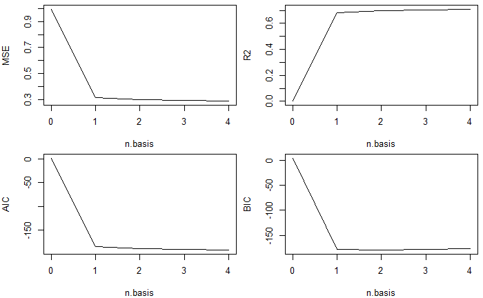

```r
plot(SVD.cv.4py)
```

```r
SVD.cv.8py <- SVDsmoothCV(D_pm, 0:4, df = 8*n_years)
print(SVD.cv.8py)
```

```
Result of SVDsmoothCV, average of CV-statistics:
```

|  | MSE | R2 | AIC | BIC |
| --- | --- | --- | --- | --- |
| n.basis.0 | 0.9935345 | 0.0000000 | 0.9967519 | 4.065383 |
| n.basis.1 | 0.3113849 | 0.6865977 | -186.9627141 | -180.825452 |
| n.basis.2 | 0.2951581 | 0.7029364 | -192.6550607 | -183.449167 |
| n.basis.3 | 0.2892771 | 0.7088534 | -194.2133067 | -181.938782 |
| n.basis.4 | 0.2828358 | 0.7153339 | -195.8266143 | -180.483459 |

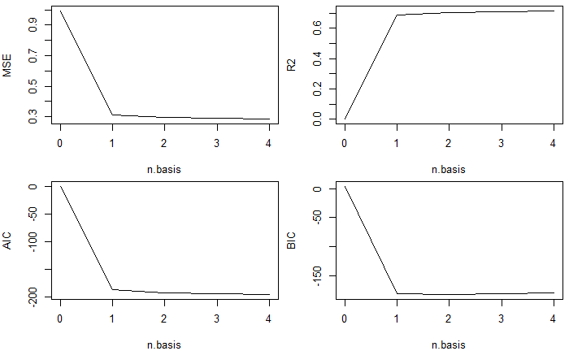

```r
plot(SVD.cv.8py)
```

```r
n_df <- 4
n_basis <- 1
```

Now, update the pm STdata object with the basis function

```r
pm_STdata <- updateTrend(pm_STdata, n.basis = n_basis, df = n_df*n_years)
```

```
Replacing existing trend.
```

```r
pm_STdata
```

```
STdata-object with:
    No. locations: 14 (observed: 9)
    No. time points: 170 (observed: 170)
    No. obs: 1392

Trend with 1 basis function(s):
[1] "V1"
with dates:
    2016-02-08 to 2019-07-29

5 covariate(s):
[1] "ID"  "x"   "y"   "lon" "lat"

No spatio-temporal covariates.
```

```r
head(pm_STdata$trend)
```

|  | V1 | date |
| --- | --- | --- |
| 1 | -0.2442076 | 2016-02-08 |
| 2 | 0.7554104 | 2016-02-15 |
| 3 | 1.0269771 | 2016-02-22 |
| 4 | 0.9081817 | 2016-02-29 |
| 5 | 0.8609696 | 2016-03-07 |
| 6 | 0.8595470 | 2016-03-14 |

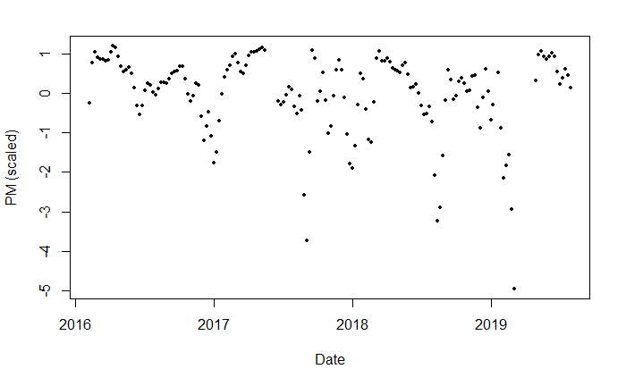

```r
plot(pm_STdata$trend$date, pm_STdata$trend$V1, col = 1, pch = 16, cex = 0.5,
     xlab = "Date", ylab = "PM (scaled)")
```

```r
denver.data2 <- denver.data
denver.data2trend <- pm_STdata$trend
print(denver.data2)
```

```
STdata-object with:
    No. locations: 61 (observed: 61)
    No. time points: 170 (observed: 170)
    No. obs: 1146

Trend with 1 basis function(s):
[1] "V1"
with dates:
    2016-02-08 to 2019-07-29

11 covariate(s):
 [1] "ID"              "lon"             "lat"             "tree_cover_100"  "low_int_100"     "dist_m_military"
 [7] "dist_m_rail"     "aadt_100"        "x"               "y"               "type"

1 spatio-temporal covariate(s):
[1] "bc_st_no2"

All sites:
central    dist
      1      60
Observed:
central    dist
      1      60

For central:
  Number of obs: 169
  Dates: 2016-02-08 to 2019-07-29
For dist:
  Number of obs: 977
  Dates: 2018-05-07 to 2019-03-04
```

### Step 10: Evaluate the basis functions using the PM data instead of the BC data

Plotting the temporal trends at a few of the sites. These should look very similar to the ones from before

```r
par(mar=c(3.3,3.3,1.5,1), mgp=c(2,1,0))
layout(matrix(c(1,1,2,2,3,4), 3, 2, byrow=TRUE))
plot(denver.data2, "obs", ID="d_1", xlab="", ylab="BC (log ug/m3)",
     main="Temporal trend d_1")
plot(denver.data2, "res", ID="d_1", xlab="", ylab="BC (log ug/m3)")
plot(denver.data2, "acf", ID="d_1")
plot(denver.data2, "pacf", ID="d_1")

par(mar=c(3.3,3.3,1.5,1), mgp=c(2,1,0))
layout(matrix(c(1,1,2,2,3,4), 3, 2, byrow=TRUE))
plot(denver.data2, "obs", ID="d_20", xlab="", ylab="BC (log ug/m3)",
     main="Temporal trend d_20")
plot(denver.data2, "res", ID="d_20", xlab="", ylab="BC (log ug/m3)")
plot(denver.data2, "acf", ID="d_20")
plot(denver.data2, "pacf", ID="d_20")

par(mar=c(3.3,3.3,1.5,1), mgp=c(2,1,0))
layout(matrix(c(1,1,2,2,3,4), 3, 2, byrow=TRUE))
plot(denver.data2, "obs", ID="d_53", xlab="", ylab="BC (log ug/m3)",
     main="Temporal trend d_53")
plot(denver.data2, "res", ID="d_53", xlab="", ylab="BC (log ug/m3)")
plot(denver.data2, "acf", ID="d_53")
plot(denver.data2, "pacf", ID="d_53")

par(mar=c(3.3,3.3,1.5,1), mgp=c(2,1,0))
layout(matrix(c(1,1,2,2,3,4), 3, 2, byrow=TRUE))
plot(denver.data2, "obs", ID="central", xlab="", ylab="BC (log ug/m3)",
     main="Temporal trend central")
plot(denver.data2, "res", ID="central", xlab="", ylab="BC (log ug/m3)")
plot(denver.data2, "acf", ID="central")
plot(denver.data2, "pacf", ID="central")
```

[output not shown]

### Step 11: Create the model object (exp covariance structure) using the new trend data

```r
names(denver.data2$covars)
```

[output not shown]

### Step 12: Fit the new model

Going with the initia values that were close to the “best” model last time

```r
dim <- loglikeSTdim(denver.model.exp2)
# dim
names <- loglikeSTnames(denver.model.exp2, all=FALSE)
names
```

```
[1] "log.range.const.exp"           "log.sill.const.exp"            "log.nugget.const.exp"
[4] "log.nugget.V1.iid"             "nu.log.range.exp"              "nu.log.sill.exp"
[7] "nu.log.nugget.(Intercept).exp"
```

```r
x.init.exp2 <- cbind(c(0, 0, 0, 0, 0, 0, 0),
                    c(4, -1, -1, -1, 4, -1, -1),
                    c(4, -1, -5, -5, 4, -1, -1),
                    c(4, -5, -1, -1, 4, -5, -5),
                    c(4, -5, -5, -5, 4, -5, -5)
                    )
x.init.exp2[nrow(x.init.exp2),] <- 0

rownames(x.init.exp2) <- loglikeSTnames(denver.model.exp2, all=FALSE)
x.init.exp2
```

```
                              [,1] [,2] [,3] [,4] [,5]
log.range.const.exp              0    4    4    4    4
log.sill.const.exp               0   -1   -1   -5   -5
log.nugget.const.exp             0   -1   -5   -1   -5
log.nugget.V1.iid                0   -1   -5   -1   -5
nu.log.range.exp                 0    4    4    4    4
nu.log.sill.exp                  0   -1   -1   -5   -5
nu.log.nugget.(Intercept).exp    0    0    0    0    0
```

```r
#' Difference from tutorial: use Josh Keller's version of the function
source(here::here("Code", "functions_model.R"))
est.denver.model.exp2 <- estimate.STmodel(denver.model.exp2, x.init.exp2)
```

```
Optimisation using starting value 1/5
```

[output not shown]

```
number of items to replace is not a multiple of replacement lengthOptimisation using starting value 2/5
```

[output not shown]

```
Optimisation using starting value 3/5
```

[output not shown]

```
Optimisation using starting value 4/5
```

[output not shown]

```
Optimisation using starting value 5/5
```

[output not shown]

```r
print(est.denver.model.exp2)
```

```
Optimisation for STmodel with 5 starting points.
  Results: 4 converged, 1 not converged, 0 failed.
  Best result for starting point 4, optimisation has converged

No fixed parameters.

Estimated parameters for all starting point(s):
                                       [,1]          [,2]          [,3]          [,4]          [,5]
gamma.bc_st_no2               -5.034598e-03  -0.006884406 -6.883390e-03 -6.883683e-03 -6.884854e-03
alpha.const.(Intercept)        4.101747e-01   0.444380029  4.443503e-01  4.443270e-01  4.443660e-01
alpha.const.tree_cover_100    -1.147530e-03   0.008958104  8.955166e-03  8.951121e-03  8.956947e-03
alpha.const.low_int_100        3.256460e-03  -0.006931977 -6.921125e-03 -6.926386e-03 -6.924676e-03
alpha.const.dist_m_military   -7.329231e-03  -0.013384498 -1.338814e-02 -1.339159e-02 -1.338925e-02
alpha.const.dist_m_rail        3.865002e-03   0.004953257  4.956233e-03  4.963254e-03  4.962429e-03
alpha.const.aadt_100           4.371809e-02   0.044199687  4.421881e-02  4.419217e-02  4.421046e-02
alpha.V1.(Intercept)          -3.122251e-01  -0.327626938 -3.275976e-01 -3.275710e-01 -3.276039e-01
alpha.V1.tree_cover_100        1.158010e-02   0.000661156  6.639508e-04  6.608703e-04  6.600253e-04
alpha.V1.low_int_100           1.143389e-02   0.014972181  1.496968e-02  1.498063e-02  1.497258e-02
alpha.V1.dist_m_military       6.931269e-04   0.009853794  9.852449e-03  9.851175e-03  9.863179e-03
alpha.V1.dist_m_rail          -5.953636e-02  -0.048137747 -4.815009e-02 -4.815546e-02 -4.814741e-02
alpha.V1.aadt_100              5.524499e-02   0.056321460  5.633393e-02  5.639704e-02  5.632574e-02
log.range.const.exp            0.000000e+00   3.600999979  4.005547e+00  3.442979e+00  3.985245e+00
log.sill.const.exp            -6.177789e+00  -6.072026000 -6.076982e+00 -6.067227e+00 -6.079062e+00
log.nugget.const.exp          -1.285012e+01 -15.000000000 -1.117046e+01 -1.500000e+01 -1.043036e+01
log.nugget.V1.iid             -5.723433e+00  -5.868538214 -5.866553e+00 -5.861486e+00 -5.866325e+00
nu.log.range.exp               0.000000e+00   8.598077583  8.597236e+00  8.598088e+00  8.597610e+00
nu.log.sill.exp               -2.638822e+00  -2.267493495 -2.267469e+00 -2.267991e+00 -2.267671e+00
nu.log.nugget.(Intercept).exp -2.616949e+00  -2.908402682 -2.908851e+00 -2.908150e+00 -2.908573e+00

Function value(s):
[1] 522.1327 558.0034 557.9982 558.0034 557.9938
```

### Step 13: Cross-validation and model evaluation using the updated time trends

#### Step 13.1: Define CV groups

```r
Ind.cv2 <- createCV(denver.model.exp2, groups = 10, min.dist = .1,
                   subset = paste0("d_", 1:60))
```

The number of locations is roughly even, though the number of observations differs by group– remember! This is an unbalanced design

```r
ID.cv2 <- sapply(split(denver.model.exp2$obs$ID, Ind.cv2), unique)
print(sapply(ID.cv2, length))
```

```
 0  1  2  3  4  5  6  7  8  9 10
 1  6  6  6  6  6  6  6  6  6  6
```

```r
table(Ind.cv2)
```

```
Ind.cv2
  0   1   2   3   4   5   6   7   8   9  10
169 100 101 102 115 103  82  86  86  94 108
```

```r
I.col2 <- apply(sapply(ID.cv2,function(x) denver.model.exp2$locations$ID%in% x), 1,
               function(x) if(sum(x)==1) which(x) else 0)
names(I.col2) <- denver.model.exp2$locations$ID
print(I.col2)
```

```
central     d_2     d_4     d_6     d_8    d_12    d_14    d_16    d_18    d_20    d_22    d_24    d_26     d_5     d_7
      1       6       9      11       4      11       2       8      11       9       7       2       9      10       2
   d_11    d_13    d_15    d_17    d_19    d_21    d_23    d_25     d_3    d_10    d_28    d_30    d_32    d_34    d_36
     10      11       6      11       6      10       3       3       8       8       3       5      10       5       4
   d_38    d_40    d_41    d_42    d_43    d_44    d_45     d_1     d_9    d_27    d_29    d_31    d_33    d_37    d_39
      5       4       7       2       7       8       6       2       5       5       4       7       5       9       4
   d_35    d_49    d_51    d_52    d_55    d_56    d_46    d_47    d_50    d_53    d_54    d_48    d_57    d_58    d_59
      3       6       8      11       4       9       9       8      10       2       6       3       3       7       7
   d_60
     10
```

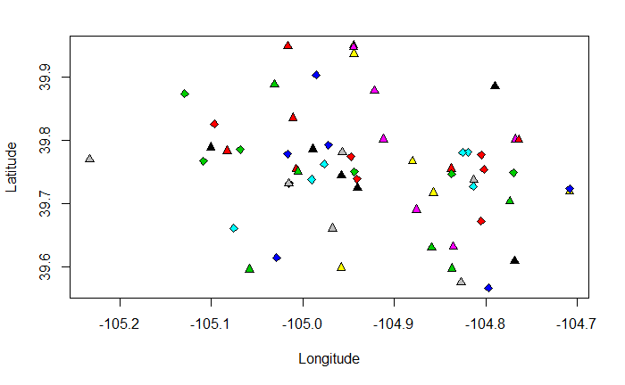

```r
par(mfrow=c(1,1))
plot(denver.model.exp$locations$long,
     denver.model.exp$locations$lat,
     pch=23+floor(I.col/max(I.col)+.5), bg=I.col,
     xlab="Longitude", ylab="Latitude")
```

```r
map("county", "colorado", col="#FFFF0055",fill=TRUE, add=TRUE)
```

#### Step 13.2: ID starting conditions using previous model without CV

|  | par | init |
| --- | --- | --- |
| log.range.const.exp | 3.442979 | 4 |
| log.sill.const.exp | -6.067227 | -5 |
| log.nugget.const.exp | -15.000000 | -1 |
| log.nugget.V1.iid | -5.861486 | -1 |
| nu.log.range.exp | 8.598088 | 4 |
| nu.log.sill.exp | -2.267991 | -5 |
| nu.log.nugget.(Intercept).exp | -2.908150 | 0 |

#### Step 13.3 : Run the model

```r
est.denver.cv.exp2 <- estimateCV(denver.model.exp2, x.init.cv2, Ind.cv2)
```

```
Estimation of CV-set 1/10
Optimisation using starting value 1/2
```

[output not shown]

```
Optimisation using starting value 2/2
```

[output not shown]

```
Estimation of CV-set 2/10
Optimisation using starting value 1/2
```

[output not shown]

```
Optimisation using starting value 2/2
```

[output not shown]

```
Estimation of CV-set 3/10
Optimisation using starting value 1/2
```

[output not shown]

```
Optimisation using starting value 2/2
```

[output not shown]

```
Estimation of CV-set 4/10
Optimisation using starting value 1/2
```

[output not shown]

```
Optimisation using starting value 2/2
```

[output not shown]

```
Estimation of CV-set 5/10
Optimisation using starting value 1/2
```

[output not shown]

```
Optimisation using starting value 2/2
```

[output not shown]

```
Estimation of CV-set 6/10
Optimisation using starting value 1/2
```

[output not shown]

```
Optimisation using starting value 2/2
```

[output not shown]

```
Estimation of CV-set 7/10
Optimisation using starting value 1/2
```

[output not shown]

```
Optimisation using starting value 2/2
```

[output not shown]

```
Estimation of CV-set 8/10
Optimisation using starting value 1/2
```

[output not shown]

```
Optimisation using starting value 2/2
```

[output not shown]

```
Estimation of CV-set 9/10
Optimisation using starting value 1/2
```

[output not shown]

```
Optimisation using starting value 2/2
```

[output not shown]

```
Estimation of CV-set 10/10
Optimisation using starting value 1/2
```

[output not shown]

```
Optimisation using starting value 2/2
```

[output not shown]

```r
print(est.denver.cv.exp2)
```

```
Cross-validation parameter estimation for STmodel
  with 10 CV-groups and 2 starting points.
  Results: 6 converged, 4 not converged.

No fixed parameters.

Estimated function values and convergence info:
```

| value | convergence | conv | eigen.min | eigen.all.min |
| --- | --- | --- | --- | --- |
| 520.1984 | TRUE | TRUE | 1.833164e-04 | NA |
| 531.7903 | TRUE | TRUE | 2.261987e-04 | NA |
| 486.0311 | TRUE | TRUE | 2.530372e-04 | NA |
| 471.9826 | TRUE | TRUE | 1.379200e-04 | NA |
| 489.6314 | TRUE | FALSE | -1.308444e-06 | NA |
| 490.8632 | TRUE | FALSE | -6.967710e-05 | NA |
| 616.5325 | TRUE | TRUE | 2.626459e-06 | NA |
| 611.5582 | TRUE | FALSE | -4.257679e-03 | NA |
| 485.9934 | TRUE | TRUE | 1.034207e-04 | NA |
| 482.2819 | TRUE | FALSE | -1.398316e-05 | NA |

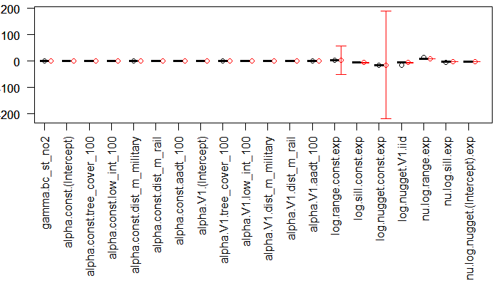

```r
par(mfrow=c(1,1), mar=c(13.5,2.5,.5,.5), las=2)
with(coef(est.denver.model.exp2, pars="all"),
     plotCI((1:length(par))+.3, par, uiw=1.96*sd,
            col=2, xlab="", xaxt="n", ylab=""))
boxplot(est.denver.cv.exp2, "all", boxwex=.4, col="grey", add=TRUE)
```

```r
#' Save the results as an .rdata object
save(denver.data, denver.model.iid, denver.model.exp,
     est.denver.model.iid, est.denver.model.exp,
     est.denver.cv.exp,
     denver.model.exp2, est.denver.model.exp2,
     est.denver.cv.exp2,
     file = here::here("Results", "Denver_ST_Model.rdata"))
```

### Step 14: Prediction using the CV model with the longer time period

Makinf predctions using the CV model. Printing out the CV summary statistics as well

```r
pred.cv2 <- predictCV(denver.model.exp2, est.denver.cv.exp2, LTA = T)
pred.cv.log2 <- predictCV(denver.model.exp2, est.denver.cv.exp2,
                          LTA = T, transform="unbiased")

names(pred.cv2)
```

```
[1] "opts"     "Ind.cv"   "pred.obs" "pred.LTA" "pred.all"
```

```r
summary(pred.cv2)
```

```
Cross-validation predictions for STmodel with 10 CV-groups.
  Predictions for 977 observations.
  Temporal averages for 60 locations.

RMSE:
            EX.mu EX.mu.beta        EX
obs     0.4155830  0.4154275 0.4093468
average 0.1262554  0.1257642 0.1189737

R2:
            EX.mu EX.mu.beta        EX
obs     0.2938533  0.2943818 0.3148870
average 0.3214150  0.3266851 0.3974323

Coverage of 95% prediction intervals:
               EX
obs     0.9570113
average 0.9166667
```

```r
summary(pred.cv.log2)
```

```
Cross-validation predictions for STmodel with 10 CV-groups.
  Predictions for 977 observations.
  Temporal averages for 60 locations.

RMSE:
            EX.mu EX.mu.beta        EX   EX.pred
obs     0.5886848  0.5881065 0.5346211 0.5333259
average 0.2105338  0.2089447 0.1702953 0.1700481

R2:
            EX.mu EX.mu.beta        EX   EX.pred
obs     0.3793045  0.3805234 0.4880764 0.4905539
average 0.2708672  0.2818324 0.5229451 0.5243292

Coverage of 95% prediction intervals:
          EX.pred
obs     0.9570113
average 0.9500000
```

```r
par(mfrow=c(1,2), mar=c(3.3,3.3,1.5,1), mgp=c(2,1,0))
plot(pred.cv2, "obs", ID="all", pch=c(19,NA), cex=.25, lty=c(NA,2),
     col=c("ID", "black", "grey"),
     ylim=c(-1,2),
     xlab="Observations", ylab="Predictions",
     main="Cross-validation BC (log ug/m3)")
with(pred.cv.log2$pred.LTA, plotCI(obs, EX.pred, uiw=1.96*sqrt(VX.pred),
                                  xlab="Observations", ylab="Predictions",
                                  main="Temporal average BC (ug/m3)"))
```

[figure not shown]

```r
abline(0, 1, col="grey")
```

### Step 15 Predictions for the full grid

**Will need to discuss with Josh at our next meeting**

```r
grid_no2 <- data.frame()
pol <- "idw_no2"

for(i in 1:length(summer_dates)) {
  df <- read_csv(here::here("Data/Grid_ST_Data",
                            paste0("grid_st_cov_", summer_dates[i], ".csv"))) %>%
    arrange(grid_id) %>%
    mutate(date = summer_dates[i]) %>%
    select(grid_id, pol, date)
  df2 <- df %>%
    pivot_wider(id_cols = date, names_from = grid_id, values_from = idw_no2)

  grid_no2 <- bind_rows(grid_no2, df2)
  rm(df, df2)
}
```

#### All of Josh Keller’s advice for fitting the model

Pasting here for safe keeping

Your sleuthing about that error is correct. A singular hessian matrix (the hessian is a like a matrix analogue of a second derivative) is symptomatic of the optimization algorithm not finding the true minimum. I remember this error all too well! To deal with this, I suggest the following:

- Use the version of estimate.STmodel() in the attached file instead of the one that is in the package. If you load the package, then source this file, it will overwrite the package function so you can use this version. This version has two changes:
  - It changes the error handling to catch the non-invertible warning and output an obviously wrong value for the standard deviation (-1000). This doesn’t fix the problem at all, but keeps the function from aborting, as the package version does, since the abort makes you lose all of your results that far. This makes it more practical to use multiple starting values in a single function call, since it won’t abort half way through.
  - It uses the function hessian() from the `numDeriv` package to provide a more numerically-accurate estimate of the Hessian matrix. The package version of the hessian is still stored in the `optim_hessian` object, while the new version is in the `hessian` object. This means you’ll need to install the numDeriv package.
- Try a set of different initial conditions. The numerical algorithm used to maximize the likelihood can get stuck in some areas, so using a set of several initial conditions is a good way to try to ensure that you’re getting the best solution. The package should be able to loop through several initial values and pick the one giving the best result. Let me know if you’d like any suggested values to try.
- Try a simpler model. I’m not sure exactly what model structure you’re using, but it often helps to start with a smaller model (e.g. 1 time trend, and iid covariance structure) to get a sense of the ranges of the parameters. You can then use the estimates from the simpler model as approximate starting values for a more complicated fit.